# Practical Homework 1

Badamgarav Battushig

2026-04-19

### Youth Substance Use Prediction using Tree-Based Models

#### Theoretical Background

Decision trees are supervised learning methods that divide the predictor space into smaller regions through recursive binary splitting. In classification, each split is chosen to make the resulting groups more homogeneous in terms of class membership, while in regression the splits are chosen to reduce variation within the response. A major strength of decision trees is interpretability, because the final model can be read as a sequence of simple decision rules. However, a single tree can be unstable and may overfit the training data, which is why pruning and tuning are important. The complexity parameter helps control tree size by removing unnecessary splits. Random forests extend this idea by averaging many trees built from bootstrap samples and random subsets of predictors, which reduces variance and often improves predictive performance. Boosting also combines many trees, but it builds them sequentially so that each new tree focuses on correcting previous errors. Because of these differences, tree-based methods provide a flexible set of tools for binary classification, multi-class classification, and regression.

### Data Type Comparison

The same set of demographic, behavioral, and social variables was used across all models. However, for each task, the response variable was excluded from the predictor set, resulting in slightly different input features depending on the modeling objective..

**Original dataset size: 10,561 rows and 79 columns** **Final modeling dataset size: 9,199 rows and 14 columns**

### Load Required Libraries

```r
library(tidyverse)
library(caret)
```

```r
library(rpart)
library(rpart.plot)
library(randomForest)
library(gbm)
library(dplyr)
```

### Load Dataset

```r
load("C:/Users/badam/OneDrive/Desktop/Data 5322 ML2/Practice HW 1/youth_data.Rdata")
head(df)
```

```
##   IRALCFY IRMJFY IRCIGFM IRSMKLSS30N IRALCFM IRMJFM IRCIGAGE IRSMKLSSTRY
## 1     991    991      91          91      91     91      991         991
## 2     991     60      91          91      91      2      991         991
## 3       1    991      91          91      93     91      991         991
## 4     991    991      91          91      91     91      991         991
## 5     991    991      91          91      91     91      991         991
## 6     991    991      91          91      91     91      991         991
##   IRALCAGE IRMJAGE MRJFLAG ALCFLAG TOBFLAG ALCYDAYS MRJYDAYS ALCMDAYS MRJMDAYS
## 1      991     991       0       0       0        6        6        5        5
## 2      991      14       1       0       0        6        3        5        1
## 3       11     991       0       1       0        1        6        5        5
## 4      991     991       0       0       0        6        6        5        5
## 5      991     991       0       0       0        6        6        5        5
## 6      991     991       0       0       0        6        6        5        5
##   CIGMDAYS SMKLSMDAYS SCHFELT TCHGJOB AVGGRADE STNDSCIG STNDSMJ STNDALC STNDDNK
```

[output cut: 55 more lines]

### Understanding the Dataset

The dataset `youth_data` is used as the main dataset for this analysis. It includes demographic variables, youth experiences, and substance use information.

```r
# Rename df to youth_data for clarity
youth_data <- df

# check dataset size
dim(youth_data)
```

```
## [1] 10561    79
```

```r
# inspect structure
str(youth_data)
```

```
## 'data.frame':    10561 obs. of  79 variables:
##  $ IRALCFY    : num  991 991 1 991 991 991 991 993 991 991 ...
##   ..- attr(*, "label")= chr "ALCOHOL FREQUENCY PAST YEAR - IMPUTATION REVISED"
##   ..- attr(*, "format.sas")= chr "IRALCFYFMT"
##  $ IRMJFY     : num  991 60 991 991 991 991 991 991 991 991 ...
##   ..- attr(*, "label")= chr "MARIJUANA FREQUENCY PAST YEAR - IMPUTATION REVISED"
##   ..- attr(*, "format.sas")= chr "IRMJFYFMT"
##  $ IRCIGFM    : num  91 91 91 91 91 91 91 91 91 91 ...
##   ..- attr(*, "label")= chr "CIG FREQUENCY PAST MONTH - IMPUTATION REVISED"
##   ..- attr(*, "format.sas")= chr "IRCIGFMFMT"
##  $ IRSMKLSS30N: num  91 91 91 91 91 91 91 91 91 91 ...
##   ..- attr(*, "label")= chr "SMOKELESS TOBACCO FREQUENCY PAST MONTH - IMPUTATION REVISED"
##   ..- attr(*, "format.sas")= chr "IRSMKLSS30NFMT"
##  $ IRALCFM    : num  91 91 93 91 91 91 91 93 91 91 ...
##   ..- attr(*, "label")= chr "ALCOHOL FREQUENCY PAST MONTH - IMPUTATION REVISED"
##   ..- attr(*, "format.sas")= chr "IRALCFMFMT"
##  $ IRMJFM     : num  91 2 91 91 91 91 91 91 91 91 ...
##   ..- attr(*, "label")= chr "MARIJUANA FREQUENCY PAST MONTH - IMPUTATION REVISED"
##   ..- attr(*, "format.sas")= chr "IRMJFMFMT"
##  $ IRCIGAGE   : num  991 991 991 991 991 991 991 991 991 991 ...
##   ..- attr(*, "label")= chr "CIGARETTE AGE OF FIRST USE - IMPUTATION REVISED"
##   ..- attr(*, "format.sas")= chr "IRCIGAGEFMT"
##  $ IRSMKLSSTRY: num  991 991 991 991 991 991 991 991 991 991 ...
##   ..- attr(*, "label")= chr "SMOKELESS TOBACCO AGE OF FIRST USE - IMPUTATION REVISED"
##   ..- attr(*, "format.sas")= chr "IRSMKLSSTRYFMT"
##  $ IRALCAGE   : num  991 991 11 991 991 991 991 12 991 991 ...
##   ..- attr(*, "label")= chr "ALCOHOL AGE OF FIRST USE - IMPUTATION REVISED"
##   ..- attr(*, "format.sas")= chr "IRALCAGEFMT"
##  $ IRMJAGE    : num  991 14 991 991 991 991 991 991 991 991 ...
##   ..- attr(*, "label")= chr "MARIJUANA AGE OF FIRST USE - IMPUTATION REVISED"
##   ..- attr(*, "format.sas")= chr "IRMJAGEFMT"
##  $ MRJFLAG    : Factor w/ 2 levels "0","1": 1 2 1 1 1 1 1 1 1 1 ...
##  $ ALCFLAG    : Factor w/ 2 levels "0","1": 1 1 2 1 1 1 1 2 1 1 ...
##  $ TOBFLAG    : Factor w/ 2 levels "0","1": 1 1 1 1 1 1 1 1 1 1 ...
##  $ ALCYDAYS   : num  6 6 1 6 6 6 6 6 6 6 ...
##   ..- attr(*, "label")= chr "RC-# OF DAYS USED ALCOHOL IN PAST YEAR"
##   ..- attr(*, "format.sas")= chr "ALCYDAYSFMT"
##  $ MRJYDAYS   : num  6 3 6 6 6 6 6 6 6 6 ...
##   ..- attr(*, "label")= chr "RC-# OF DAYS USED MARIJUANA IN PAST YEAR"
##   ..- attr(*, "format.sas")= chr "MRJYDAYSFMT"
```

[output cut: 59 more lines]

```
##  $ IRSEX      : Factor w/ 2 levels "1","2": 1 2 1 2 1 1 2 1 2 1 ...
##  $ NEWRACE2   : Factor w/ 7 levels "1","2","3","4",..: 7 1 6 7 1 7 4 2 2 1 ...
##  $ HEALTH2    : Ord.factor w/ 4 levels "1"<"2"<"3"<"4": 3 4 1 2 1 1 2 2 2 1 ...
##  $ EDUSCHLGO  : Factor w/ 7 levels "1","2","11","85",..: 1 1 1 1 1 2 1 1 2 1 ...
##  $ EDUSCHGRD2 : Ord.factor w/ 12 levels "1"<"2"<"3"<"4"<..: 3 6 2 2 5 12 6 4 12 6 ...
##  $ EDUSKPCOM  : num  0 0 1 0 0 99 5 10 99 0 ...
##   ..- attr(*, "label")= chr "RC - HOW MANY DAYS MISSED SCHOOL FROM SKIPPING (COMBINED)"
##   ..- attr(*, "format.sas")= chr "EDUSKPCOMFMT"
##  $ IMOTHER    : Factor w/ 3 levels "1","2","3": 1 1 1 1 1 2 1 1 1 1 ...
##  $ IFATHER    : Factor w/ 3 levels "1","2","3": 1 1 1 1 1 1 1 2 2 1 ...
##  $ INCOME     : Ord.factor w/ 4 levels "1"<"2"<"3"<"4": 2 2 4 3 4 3 3 2 3 4 ...
##  $ GOVTPROG   : Factor w/ 2 levels "1","2": 2 2 2 2 2 2 1 1 2 2 ...
##  $ POVERTY3   : Ord.factor w/ 3 levels "1"<"2"<"3": 1 1 3 2 3 3 3 1 2 3 ...
##  $ PDEN10     : Factor w/ 3 levels "1","2","3": 2 2 1 1 2 1 2 1 1 1 ...
##  $ COUTYP4    : Factor w/ 3 levels "1","2","3": 2 2 1 1 2 1 2 1 1 1 ...
```

```r
# summary statistics
summary(youth_data)
```

```
##     IRALCFY          IRMJFY         IRCIGFM       IRSMKLSS30N
##  Min.   :  1.0   Min.   :  1.0   Min.   : 1.00   Min.   : 1.00
##  1st Qu.:991.0   1st Qu.:991.0   1st Qu.:91.00   1st Qu.:91.00
##  Median :991.0   Median :991.0   Median :91.00   Median :91.00
##  Mean   :820.1   Mean   :876.9   Mean   :89.94   Mean   :90.78
##  3rd Qu.:991.0   3rd Qu.:991.0   3rd Qu.:91.00   3rd Qu.:91.00
##  Max.   :993.0   Max.   :993.0   Max.   :93.00   Max.   :93.00
##
##     IRALCFM          IRMJFM         IRCIGAGE      IRSMKLSSTRY
##  Min.   : 1.00   Min.   : 1.00   Min.   :  1.0   Min.   :  7.0
##  1st Qu.:91.00   1st Qu.:91.00   1st Qu.:991.0   1st Qu.:991.0
##  Median :91.00   Median :91.00   Median :991.0   Median :991.0
##  Mean   :85.21   Mean   :85.49   Mean   :920.1   Mean   :976.1
##  3rd Qu.:91.00   3rd Qu.:91.00   3rd Qu.:991.0   3rd Qu.:991.0
##  Max.   :93.00   Max.   :93.00   Max.   :991.0   Max.   :991.0
##
##     IRALCAGE        IRMJAGE      MRJFLAG  ALCFLAG  TOBFLAG     ALCYDAYS
##  Min.   :  1.0   Min.   :  4.0   0:8971   0:8157   0:9603   Min.   :1.000
##  1st Qu.:991.0   1st Qu.:991.0   1:1590   1:2404   1: 958   1st Qu.:6.000
##  Median :991.0   Median :991.0                              Median :6.000
##  Mean   :768.5   Mean   :843.9                              Mean   :5.224
##  3rd Qu.:991.0   3rd Qu.:991.0                              3rd Qu.:6.000
##  Max.   :991.0   Max.   :991.0                              Max.   :6.000
##
##     MRJYDAYS        ALCMDAYS        MRJMDAYS        CIGMDAYS
##  Min.   :1.000   Min.   :1.000   Min.   :1.000   Min.   :1.000
##  1st Qu.:6.000   1st Qu.:5.000   1st Qu.:5.000   1st Qu.:6.000
##  Median :6.000   Median :5.000   Median :5.000   Median :6.000
##  Mean   :5.557   Mean   :4.756   Mean   :4.826   Mean   :5.943
##  3rd Qu.:6.000   3rd Qu.:5.000   3rd Qu.:5.000   3rd Qu.:6.000
##  Max.   :6.000   Max.   :5.000   Max.   :5.000   Max.   :6.000
##
##    SMKLSMDAYS    SCHFELT  TCHGJOB     AVGGRADE    STNDSCIG    STNDSMJ
##  Min.   :1.000   1:7491   1   :7807   1   : 574   1   :1333   1   :2762
##  1st Qu.:5.000   2:3070   2   :2711   2   :9271   2   :8851   2   :7354
##  Median :5.000            NA's:  43   NA's: 716   NA's: 377   NA's: 445
##  Mean   :4.992
##  3rd Qu.:5.000
##  Max.   :5.000
##
```

[output cut: 57 more lines]

```
##  1:5387   1:4750   1   :2831   1 :9378   5      :1704   Min.   : 0.00
##  2:5174   2:1284   2   :4031   2 : 999   6      :1673   1st Qu.: 0.00
##           3: 368   3   :2771   11:  22   4      :1589   Median : 0.00
##           4:  50   4   : 915   85:  21   7      :1584   Mean   :27.02
##           5: 503   NA's:  13   94:  85   3      :1370   3rd Qu.:98.00
##           6: 795               97:  46   99     : 999   Max.   :99.00
##           7:2811               98:  10   (Other):1642
##  IMOTHER  IFATHER  INCOME   GOVTPROG POVERTY3 PDEN10   COUTYP4
##  1:9612   1:7514   1:1400   1:3122   1:2433   1:4617   1:4897
##  2: 897   2:2974   2:2766   2:7439   2:2299   2:5353   2:4037
##  3:  52   3:  73   3:1482            3:5829   3: 591   3:1627
##                    4:4913
##
##
##
```

```r
# column names
colnames(youth_data)
```

```
##  [1] "IRALCFY"     "IRMJFY"      "IRCIGFM"     "IRSMKLSS30N" "IRALCFM"
##  [6] "IRMJFM"      "IRCIGAGE"    "IRSMKLSSTRY" "IRALCAGE"    "IRMJAGE"
## [11] "MRJFLAG"     "ALCFLAG"     "TOBFLAG"     "ALCYDAYS"    "MRJYDAYS"
## [16] "ALCMDAYS"    "MRJMDAYS"    "CIGMDAYS"    "SMKLSMDAYS"  "SCHFELT"
## [21] "TCHGJOB"     "AVGGRADE"    "STNDSCIG"    "STNDSMJ"     "STNDALC"
## [26] "STNDDNK"     "PARCHKHW"    "PARHLPHW"    "PRCHORE2"    "PRLMTTV2"
## [31] "PARLMTSN"    "PRGDJOB2"    "PRPROUD2"    "ARGUPAR"     "YOFIGHT2"
## [36] "YOGRPFT2"    "YOHGUN2"     "YOSELL2"     "YOSTOLE2"    "YOATTAK2"
## [41] "PRPKCIG2"    "PRMJEVR2"    "PRMJMO"      "PRALDLY2"    "YFLPKCG2"
## [46] "YFLTMRJ2"    "YFLMJMO"     "YFLADLY2"    "FRDPCIG2"    "FRDMEVR2"
## [51] "FRDMJMON"    "FRDADLY2"    "TALKPROB"    "PRTALK3"     "PRBSOLV2"
## [56] "PREVIOL2"    "PRVDRGO2"    "GRPCNSL2"    "PREGPGM2"    "YTHACT2"
## [61] "DRPRVME3"    "ANYEDUC3"    "RLGATTD"     "RLGIMPT"     "RLGDCSN"
## [66] "RLGFRND"     "IRSEX"       "NEWRACE2"    "HEALTH2"     "EDUSCHLGO"
## [71] "EDUSCHGRD2"  "EDUSKPCOM"   "IMOTHER"     "IFATHER"     "INCOME"
## [76] "GOVTPROG"    "POVERTY3"    "PDEN10"      "COUTYP4"
```

```r
# See variables in each group
demographic_cols
```

```
##  [1] "IRSEX"      "NEWRACE2"   "HEALTH2"    "EDUSCHLGO"  "EDUSCHGRD2"
##  [6] "EDUSKPCOM"  "IMOTHER"    "IFATHER"    "INCOME"     "GOVTPROG"
## [11] "POVERTY3"   "PDEN10"     "COUTYP4"
```

```r
substance_cols
```

```
##  [1] "IRALCFY"     "IRMJFY"      "IRCIGFM"     "IRSMKLSS30N" "IRALCFM"
##  [6] "IRMJFM"      "IRCIGAGE"    "IRSMKLSSTRY" "IRALCAGE"    "IRMJAGE"
## [11] "MRJFLAG"     "ALCFLAG"     "TOBFLAG"     "ALCYDAYS"    "MRJYDAYS"
## [16] "ALCMDAYS"    "MRJMDAYS"    "CIGMDAYS"    "SMKLSMDAYS"
```

```r
youth_experience_cols
```

```
##  [1] "SCHFELT"  "TCHGJOB"  "AVGGRADE" "STNDSCIG" "STNDSMJ"  "STNDALC"
##  [7] "STNDDNK"  "PARCHKHW" "PARHLPHW" "PRCHORE2" "PRLMTTV2" "PARLMTSN"
## [13] "PRGDJOB2" "PRPROUD2" "ARGUPAR"  "YOFIGHT2" "YOGRPFT2" "YOHGUN2"
## [19] "YOSELL2"  "YOSTOLE2" "YOATTAK2" "PRPKCIG2" "PRMJEVR2" "PRMJMO"
## [25] "PRALDLY2" "YFLPKCG2" "YFLTMRJ2" "YFLMJMO"  "YFLADLY2" "FRDPCIG2"
## [31] "FRDMEVR2" "FRDMJMON" "FRDADLY2" "TALKPROB" "PRTALK3"  "PRBSOLV2"
## [37] "PREVIOL2" "PRVDRGO2" "GRPCNSL2" "PREGPGM2" "YTHACT2"  "DRPRVME3"
## [43] "ANYEDUC3" "RLGATTD"  "RLGIMPT"  "RLGDCSN"  "RLGFRND"
```

#### Data Dictionary (Selected Variables)

The variables are grouped based on the dataset used for each model.

**1. Binary Classification Dataset (Marijuana Use)**

MRJFLAG – Marijuana use (0 = No, 1 = Yes)  
YOSELL2 – Involvement in selling-related activities  
YOFIGHT2 – Involvement in physical fights  
IRSEX – Sex (1 = Male, 2 = Female)  
INCOME – Household income level  
EDUSCHLGO – School enrollment status  
AVGGRADE – Average grades in school  
FRDMEVR2 – Friends have ever used marijuana  
PARCHKHW – Parents check homework  
RLGATTD – Religious service attendance

**2. Multi-class Classification Dataset (Marijuana Levels)**

ALCYDAYS – Number of days alcohol was used  
IRSEX – Sex (1 = Male, 2 = Female)  
INCOME – Household income level  
EDUSCHLGO – School enrollment status  
AVGGRADE – Average grades in school  
YOFIGHT2 – Involvement in physical fights  
FRDMEVR2 – Friends have ever used marijuana  
PARCHKHW – Parents check homework  
RLGATTD – Religious service attendance

### Renaming the variables

```r
youth_data <- youth_data %>%
  rename(
    Marijuana_use = MRJFLAG,
    Selling_behavior = YOSELL2,
    Physical_fight = YOFIGHT2,
    Sex = IRSEX,
    Race = NEWRACE2,
    Household_income = INCOME,
    School_enrollment = EDUSCHLGO,
    Average_grades = AVGGRADE,
    Friends_used_marijuana = FRDMEVR2,
    Parent_checks_homework = PARCHKHW,
    Religious_attendance = RLGATTD,
    Marijuana_use_level = STNDSMJ,
    Alcohol_use_days = ALCYDAYS,
    Parent_helps_homework = PARHLPHW,
  )
```

### Data Cleaning

Select Variables for Analysis

```r
youth_model_data <- youth_data[, c(
  "Marijuana_use",
  "Marijuana_use_level",
  "Alcohol_use_days",
  "Sex",
  "Race",
  "Household_income",
  "School_enrollment",
  "Average_grades",
  "Parent_checks_homework",
  "Parent_helps_homework",
  "Physical_fight",
  "Selling_behavior",
  "Friends_used_marijuana",
  "Religious_attendance"
)]

# check structure
str(youth_model_data)
```

```
## 'data.frame':    10561 obs. of  14 variables:
##  $ Marijuana_use         : Factor w/ 2 levels "0","1": 1 2 1 1 1 1 1 1 1 1 ...
##  $ Marijuana_use_level   : Factor w/ 2 levels "1","2": 2 1 2 2 2 2 1 2 1 2 ...
##  $ Alcohol_use_days      : num  6 6 1 6 6 6 6 6 6 6 ...
##   ..- attr(*, "label")= chr "RC-# OF DAYS USED ALCOHOL IN PAST YEAR"
##   ..- attr(*, "format.sas")= chr "ALCYDAYSFMT"
##  $ Sex                   : Factor w/ 2 levels "1","2": 1 2 1 2 1 1 2 1 2 1 ...
##  $ Race                  : Factor w/ 7 levels "1","2","3","4",..: 7 1 6 7 1 7 4 2 2 1 ...
##  $ Household_income      : Ord.factor w/ 4 levels "1"<"2"<"3"<"4": 2 2 4 3 4 3 3 2 3 4 ...
##  $ School_enrollment     : Factor w/ 7 levels "1","2","11","85",..: 1 1 1 1 1 2 1 1 2 1 ...
##  $ Average_grades        : Factor w/ 2 levels "1","2": 2 2 2 NA 2 2 2 2 2 2 ...
##  $ Parent_checks_homework: Factor w/ 2 levels "1","2": 1 1 1 1 2 1 1 1 1 1 ...
##  $ Parent_helps_homework : Factor w/ 2 levels "1","2": 1 1 1 2 1 1 1 1 1 1 ...
##  $ Physical_fight        : Factor w/ 2 levels "1","2": 2 2 1 2 2 2 2 1 2 2 ...
##  $ Selling_behavior      : Factor w/ 2 levels "1","2": 2 2 2 2 2 2 2 2 2 2 ...
##  $ Friends_used_marijuana: Factor w/ 2 levels "1","2": 1 2 1 1 1 1 1 1 1 1 ...
##  $ Religious_attendance  : Factor w/ 2 levels "1","2": 2 2 2 2 2 2 2 1 2 1 ...
```

```r
# Handle Missing Values remove incomplete observations for modeling

youth_model_data <- na.omit(youth_model_data)

# check the size of the cleaned dataset
dim(youth_model_data)
```

```
## [1] 9199   14
```

```r
youth_model_data[youth_model_data %in% c(91, 93, 94, 97, 98)] <- NA

# check how many missing values were created
colSums(is.na(youth_model_data))
```

```
##          Marijuana_use    Marijuana_use_level       Alcohol_use_days
##                      0                      0                      0
##                    Sex                   Race       Household_income
##                      0                      0                      0
##      School_enrollment         Average_grades Parent_checks_homework
##                      0                      0                      0
##  Parent_helps_homework         Physical_fight       Selling_behavior
##                      0                      0                      0
## Friends_used_marijuana   Religious_attendance
##                      0                      0
```

The original dataset contained 10,561 observations and 79 variables. For this analysis, 14 relevant variables were selected based on the modeling goals. After removing incomplete observations, the final dataset contained 9,199 complete cases. This means 1,362 observations were excluded during data cleaning.

```r
# Check Class Distribution check how many users vs non-users

table(youth_model_data$Marijuana_use)
```

```
##
##    0    1
## 7730 1469
```

```r
# check proportions (class imbalance)
prop.table(table(youth_model_data$Marijuana_use))
```

```
##
##         0         1
## 0.8403087 0.1596913
```

**The dataset is imbalanced (more non-users than users) this may affect model performance and interpretation**

### 1. Binary Classification (Marijuana_use)

The predictors include demographic, behavioral, and social variables such as sex, race, household income, school enrollment, academic performance, parental involvement, physical fighting, selling behavior, peer marijuana use, and religious attendance. The variables Marijuana_use_level and Alcohol_use_days were excluded to avoid using related outcome information.

#### Model Setup

```r
# Train/Test Split
set.seed(123)

train_index <- createDataPartition(
  youth_model_data$Marijuana_use,
  p = 0.7,
  list = FALSE
)

train_data <- youth_model_data[train_index, ]
test_data  <- youth_model_data[-train_index, ]

# check sizes
dim(train_data)
```

```
## [1] 6440   14
```

```r
dim(test_data)
```

```
## [1] 2759   14
```

After splitting, the training dataset contains 6,440 observations and the testing dataset contains 2,759 observations. These datasets will be used to train the model and then evaluate its performance on unseen data.

```r
# Cross-Validation Setup use 10-fold cross-validation for tuning

ctrl <- trainControl(
  method = "cv",
  number = 10
)

# Use 10-fold cross-validation to get a more reliable model evaluation
```

#### Hyperparameter Tuning

```r
# Decision Tree Tuning Grid test different cp values to find the best tree complexity

tree_grid <- expand.grid(
  cp = seq(0.001, 0.02, by = 0.002)
)

tree_grid
```

```
##       cp
## 1  0.001
## 2  0.003
## 3  0.005
## 4  0.007
## 5  0.009
## 6  0.011
## 7  0.013
## 8  0.015
## 9  0.017
## 10 0.019
```

In this step, I created a tuning grid to test different `cp` values for the decision tree. The `cp` parameter controls the complexity of the tree, where smaller values allow more splits. I tested values from 0.001 to 0.02 to find the best balance between overfitting and underfitting.

```r
# Tune Decision Tree Model use cross-validation to find the best cp value

set.seed(123)

tree_cv <- train(
  Marijuana_use ~ .,
  data = train_data[, -which(names(train_data) %in% c("Marijuana_use_level", "Alcohol_use_days"))],
  method = "rpart",
  trControl = ctrl,
  tuneGrid = tree_grid
)

tree_cv
```

```
## CART
##
## 6440 samples
##   11 predictor
##    2 classes: '0', '1'
##
## No pre-processing
## Resampling: Cross-Validated (10 fold)
## Summary of sample sizes: 5795, 5796, 5797, 5796, 5796, 5796, ...
## Resampling results across tuning parameters:
##
##   cp     Accuracy   Kappa
##   0.001  0.8439440  0.22777244
##   0.003  0.8420792  0.19811257
##   0.005  0.8447185  0.21410637
##   0.007  0.8448745  0.18957522
##   0.009  0.8431664  0.15694630
##   0.011  0.8430111  0.14426730
##   0.013  0.8442534  0.10329070
##   0.015  0.8442534  0.10329070
##   0.017  0.8450315  0.05531553
##   0.019  0.8439445  0.04440167
##
## Accuracy was used to select the optimal model using the largest value.
## The final value used for the model was cp = 0.017.
```

The model was evaluated using 10-fold cross-validation, and accuracy was used to select the best parameter. The optimal value was cp = 0.017, which gave the highest accuracy among all tested values.

```r
# Get the Best cp Value extract the optimal cp value from cross-validation results

best_cp <- tree_cv$bestTune$cp
best_cp
```

```
## [1] 0.017
```

#### Final Model Fitting

```r
# Fit Final Decision Tree Model fit the final tree using the best cp value

tree_model <- rpart(
  Marijuana_use ~ .,
  data = train_data[, -which(names(train_data) %in% c("Marijuana_use_level", "Alcohol_use_days"))],
  method = "class",
  cp = best_cp
)
```

#### Model Evaluation

```r
# Evaluate Decision Tree Model on test data

tree_pred <- predict(tree_model, test_data, type = "class")

# Calculate accuracy
tree_accuracy <- mean(tree_pred == test_data$Marijuana_use)
tree_accuracy
```

```
## [1] 0.8481334
```

```r
# Confusion matrix
confusionMatrix(tree_pred, test_data$Marijuana_use)
```

```
## Confusion Matrix and Statistics
##
##           Reference
## Prediction    0    1
##          0 2318  418
##          1    1   22
##
##                Accuracy : 0.8481
##                  95% CI : (0.8342, 0.8613)
##     No Information Rate : 0.8405
##     P-Value [Acc > NIR] : 0.143
##
##                   Kappa : 0.0805
##
##  Mcnemar's Test P-Value : <2e-16
##
##             Sensitivity : 0.9996
##             Specificity : 0.0500
##          Pos Pred Value : 0.8472
##          Neg Pred Value : 0.9565
##              Prevalence : 0.8405
##          Detection Rate : 0.8402
##    Detection Prevalence : 0.9917
##       Balanced Accuracy : 0.5248
##
##        'Positive' Class : 0
##
```

The decision tree was evaluated using the test data. The model achieved an accuracy of about 84.8%, indicating that most observations were classified correctly.

However, the confusion matrix shows that the model predicts the majority class (non-users) very well, but struggles to correctly identify users. This is reflected in the low specificity and low kappa value, suggesting that class imbalance impacts the model’s performance.

#### Model Interpretation

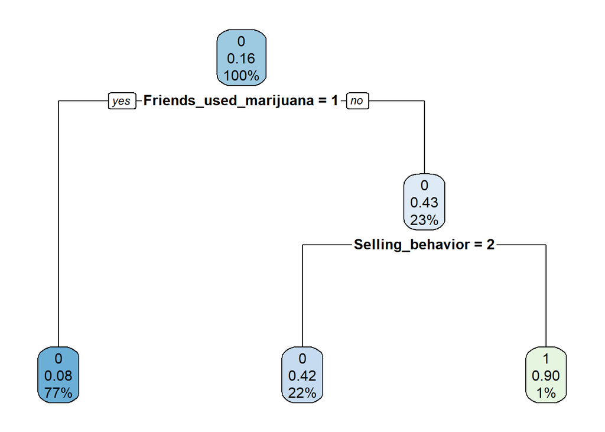

```r
# Plot Final Decision Tree display the final decision tree

rpart.plot(tree_model)
```

The decision tree shows that the first and most important split is based on whether friends use marijuana. If friends do not use marijuana, most individuals are classified as non-users.

For those whose friends use marijuana, the model further splits based on selling behavior. Individuals involved in selling-related activities are more likely to be classified as users.

## This suggests that peer influence and risky behavior play a key role in predicting marijuana use.

### 2. Random Forest Model:Marijuana Use

#### Hyperparameter Tuning

```r
# Random Forest Tuning Grid test different mtry values (number of variables at each split)

rf_grid <- expand.grid(
  mtry = 2:6
)

rf_grid
```

```
##   mtry
## 1    2
## 2    3
## 3    4
## 4    5
## 5    6
```

In this step, a tuning grid was created to test different mtry values for the random forest model. The mtry parameter controls how many variables are considered at each split. Values from 2 to 6 were tested to find the optimal setting that improves model performance.

```r
# Tune Random Forest Model use a smaller grid and fewer trees to reduce run time

set.seed(123)

rf_grid <- expand.grid(
  mtry = 2:4
)

rf_cv <- train(
  Marijuana_use ~ .,
  data = train_data[, -which(names(train_data) %in% c("Marijuana_use_level", "Alcohol_use_days"))],
  method = "rf",
  trControl = ctrl,
  tuneGrid = rf_grid,
  ntree = 100
)

rf_cv
```

```
## Random Forest
##
## 6440 samples
##   11 predictor
##    2 classes: '0', '1'
##
## No pre-processing
## Resampling: Cross-Validated (10 fold)
## Summary of sample sizes: 5795, 5796, 5797, 5796, 5796, 5796, ...
## Resampling results across tuning parameters:
##
##   mtry  Accuracy   Kappa
##   2     0.8447185  0.04848815
##   3     0.8484452  0.12944607
##   4     0.8499987  0.19974654
##
## Accuracy was used to select the optimal model using the largest value.
## The final value used for the model was mtry = 4.
```

Cross-validation was used to tune the random forest model by testing different mtry values. The model was evaluated using 10-fold cross-validation, and accuracy was used to select the best parameter. The optimal value was mtry = 4, which achieved the highest accuracy among the tested values.

```r
# Get the Best mtry Value extract the optimal mtry value from cross-validation results

best_mtry <- rf_cv$bestTune$mtry
best_mtry
```

```
## [1] 4
```

#### Final Model Fitting

```r
# Fit Final Random Forest Model fit the final random forest using the best mtry

rf_model <- randomForest(
  Marijuana_use ~ .,
  data = train_data[, -which(names(train_data) %in% c("Marijuana_use_level", "Alcohol_use_days"))],
  mtry = best_mtry,
  ntree = 100
)
```

#### Model Evaluation

```r
# Evaluate Random Forest Model make predictions on test data

rf_pred <- predict(rf_model, test_data)

# calculate accuracy
rf_accuracy <- mean(rf_pred == test_data$Marijuana_use)
rf_accuracy
```

```
## [1] 0.8481334
```

```r
# confusion matrix
confusionMatrix(rf_pred, test_data$Marijuana_use)
```

```
## Confusion Matrix and Statistics
##
##           Reference
## Prediction    0    1
##          0 2245  345
##          1   74   95
##
##                Accuracy : 0.8481
##                  95% CI : (0.8342, 0.8613)
##     No Information Rate : 0.8405
##     P-Value [Acc > NIR] : 0.143
##
##                   Kappa : 0.2452
##
##  Mcnemar's Test P-Value : <2e-16
##
##             Sensitivity : 0.9681
##             Specificity : 0.2159
##          Pos Pred Value : 0.8668
##          Neg Pred Value : 0.5621
##              Prevalence : 0.8405
##          Detection Rate : 0.8137
##    Detection Prevalence : 0.9387
##       Balanced Accuracy : 0.5920
##
##        'Positive' Class : 0
##
```

#### Model Interpretation

the random forest model was evaluated using the test data. The model achieved an accuracy of about 84.8%, similar to the decision tree.

The confusion matrix shows improved performance in identifying users compared to the decision tree, as reflected in higher specificity and kappa. However, the model still performs better at predicting the majority class, indicating that class imbalance continues to affect the results.

### 3. Boosting Model:Marijuana Use

#### Hyperparameter Tuning

```r
# Boosting Tuning Grid define parameter grid for boosting (gbm)

boost_grid <- expand.grid(
  n.trees = c(50, 100),
  interaction.depth = c(1, 2),
  shrinkage = c(0.01, 0.1),
  n.minobsinnode = 10
)

boost_grid
```

```
##   n.trees interaction.depth shrinkage n.minobsinnode
## 1      50                 1      0.01             10
## 2     100                 1      0.01             10
## 3      50                 2      0.01             10
## 4     100                 2      0.01             10
## 5      50                 1      0.10             10
## 6     100                 1      0.10             10
## 7      50                 2      0.10             10
## 8     100                 2      0.10             10
```

Tuning grid was created for the boosting model by testing different combinations of parameters. These include the number of trees, tree depth, and learning rate. This allows the model to explore different levels of complexity and find the best combination for performance.

```r
# Tune Boosting Model use cross-validation to find the best boosting parameters

set.seed(123)

boost_cv <- train(
  Marijuana_use ~ .,
  data = train_data[, -which(names(train_data) %in% c("Marijuana_use_level", "Alcohol_use_days"))],
  method = "gbm",
  trControl = ctrl,
  tuneGrid = boost_grid,
  verbose = FALSE
)

boost_cv
```

```
## Stochastic Gradient Boosting
##
## 6440 samples
##   11 predictor
##    2 classes: '0', '1'
##
## No pre-processing
## Resampling: Cross-Validated (10 fold)
## Summary of sample sizes: 5795, 5796, 5797, 5796, 5796, 5796, ...
## Resampling results across tuning parameters:
##
##   shrinkage  interaction.depth  n.trees  Accuracy   Kappa
##   0.01       1                   50      0.8402176  0.00000000
##   0.01       1                  100      0.8402176  0.00000000
##   0.01       2                   50      0.8402176  0.00000000
##   0.01       2                  100      0.8436339  0.04134437
##   0.10       1                   50      0.8476703  0.14669706
##   0.10       1                  100      0.8473587  0.21921664
##   0.10       2                   50      0.8478248  0.20687835
##   0.10       2                  100      0.8476693  0.25635422
##
## Tuning parameter 'n.minobsinnode' was held constant at a value of 10
## Accuracy was used to select the optimal model using the largest value.
## The final values used for the model were n.trees = 50, interaction.depth =
##  2, shrinkage = 0.1 and n.minobsinnode = 10.
```

Cross-validation was used to tune the boosting model by testing different parameter combinations. The model was evaluated using 10-fold cross-validation, and accuracy was used to select the best settings. The optimal parameters included a higher learning rate and deeper trees, which provided the best performance among the tested options.

```r
# Get the Best Boosting Parameters extract the optimal tuning values from cross-validation results

best_n_trees <- boost_cv$bestTune$n.trees
best_depth <- boost_cv$bestTune$interaction.depth
best_shrinkage <- boost_cv$bestTune$shrinkage
best_n_minobs <- boost_cv$bestTune$n.minobsinnode

boost_cv$bestTune
```

```
##   n.trees interaction.depth shrinkage n.minobsinnode
## 7      50                 2       0.1             10
```

The optimal boosting parameters were extracted from the cross-validation results. The best combination included 50 trees, a tree depth of 2, and a learning rate of 0.1. These values were selected because they achieved the highest accuracy among all tested combinations.

#### Final Model Fitting

```r
# Convert Response Variable for Boosting gbm with Bernoulli requires the outcome to be numeric (0 and 1)

train_boost <- train_data[, -which(names(train_data) %in% c("Marijuana_use_level", "Alcohol_use_days"))]
test_boost  <- test_data[, -which(names(test_data) %in% c("Marijuana_use_level", "Alcohol_use_days"))]

train_boost$Marijuana_use <- as.numeric(as.character(train_boost$Marijuana_use))
test_boost$Marijuana_use  <- as.numeric(as.character(test_boost$Marijuana_use))
```

```r
# Fit Final Boosting Model fit the final boosting model using the best tuning parameters

boost_model <- gbm(
  Marijuana_use ~ .,
  data = train_boost,
  distribution = "bernoulli",
  n.trees = best_n_trees,
  interaction.depth = best_depth,
  shrinkage = best_shrinkage,
  n.minobsinnode = best_n_minobs,
  verbose = FALSE
)
```

#### Model Evaluation

```r
# Evaluate Boosting Model predict probabilities and convert them to class labels

boost_prob <- predict(boost_model, test_boost, n.trees = best_n_trees, type = "response")
boost_pred <- ifelse(boost_prob > 0.5, 1, 0)

# calculate accuracy
boost_accuracy <- mean(boost_pred == test_boost$Marijuana_use)
boost_accuracy
```

```
## [1] 0.8492207
```

```r
# confusion matrix
confusionMatrix(as.factor(boost_pred), as.factor(test_boost$Marijuana_use))
```

```
## Confusion Matrix and Statistics
##
##           Reference
## Prediction    0    1
##          0 2272  369
##          1   47   71
##
##                Accuracy : 0.8492
##                  95% CI : (0.8353, 0.8624)
##     No Information Rate : 0.8405
##     P-Value [Acc > NIR] : 0.1103
##
##                   Kappa : 0.2006
##
##  Mcnemar's Test P-Value : <2e-16
##
##             Sensitivity : 0.9797
##             Specificity : 0.1614
##          Pos Pred Value : 0.8603
##          Neg Pred Value : 0.6017
##              Prevalence : 0.8405
##          Detection Rate : 0.8235
##    Detection Prevalence : 0.9572
##       Balanced Accuracy : 0.5705
##
##        'Positive' Class : 0
##
```

#### Model Interpretation

The boosting model was evaluated using the test data. The model achieved an accuracy of about 84.9%, which is slightly higher than the decision tree and random forest.

The confusion matrix shows some improvement in identifying users, but the model still performs better on the majority class. This suggests that class imbalance continues to influence the model’s performance.

The same set of demographic, behavioral, and social predictors was used. The variables Marijuana_use and Alcohol_use_days were excluded, since Marijuana_use_level is the response variable and Marijuana_use is closely related to it.

#### Model Setup

```r
# Multi-Class Decision Tree Setup create datasets for predicting marijuana use level

train_multi <- train_data[, -which(names(train_data) %in% c("Marijuana_use", "Alcohol_use_days"))]
test_multi  <- test_data[, -which(names(test_data) %in% c("Marijuana_use", "Alcohol_use_days"))]

# make sure the outcome is a factor
train_multi$Marijuana_use_level <- as.factor(train_multi$Marijuana_use_level)
test_multi$Marijuana_use_level  <- as.factor(test_multi$Marijuana_use_level)
```

#### Model Setup

```r
# Multi-Class Decision Tree Tuning Grid test different cp values for the multi-class tree

multi_grid <- expand.grid(
  cp = seq(0.001, 0.02, by = 0.002)
)
```

```r
# Tune Multi-Class Decision Treeuse cross-validation to find the best cp value

set.seed(123)

multi_cv <- train(
  Marijuana_use_level ~ .,
  data = train_multi,
  method = "rpart",
  trControl = ctrl,
  tuneGrid = multi_grid
)

multi_cv
```

```
## CART
##
## 6440 samples
##   11 predictor
##    2 classes: '1', '2'
##
## No pre-processing
## Resampling: Cross-Validated (10 fold)
## Summary of sample sizes: 5796, 5796, 5796, 5796, 5796, 5796, ...
## Resampling results across tuning parameters:
##
##   cp     Accuracy   Kappa
##   0.001  0.7534161  0.3100642
##   0.003  0.7500000  0.2909930
##   0.005  0.7504658  0.2844672
##   0.007  0.7492236  0.2725651
##   0.009  0.7467391  0.2529236
##   0.011  0.7467391  0.2514088
##   0.013  0.7467391  0.2514088
##   0.015  0.7467391  0.2514088
##   0.017  0.7448758  0.2530814
##   0.019  0.7448758  0.2530814
##
## Accuracy was used to select the optimal model using the largest value.
## The final value used for the model was cp = 0.001.
```

Cross-validation was used to tune the multi-class decision tree by testing different cp values. The model was evaluated using 10-fold cross-validation, and accuracy was used to select the best parameter. The optimal value was cp = 0.001, which achieved the highest accuracy among the tested values.

```r
# Get the Best cp Value extract the optimal cp value

best_multi_cp <- multi_cv$bestTune$cp
best_multi_cp
```

```
## [1] 0.001
```

#### Final Model Fitting

```r
# Fit Final Multi-Class Decision Tree fit the final multi-class tree using the best cp value

multi_model <- rpart(
  Marijuana_use_level ~ .,
  data = train_multi,
  method = "class",
  cp = best_multi_cp
)
```

#### Model Evaluation

```r
# Evaluate Multi-Class Decision Tree make predictions on the test data

multi_pred <- predict(multi_model, test_multi, type = "class")

# calculate accuracy
multi_accuracy <- mean(multi_pred == test_multi$Marijuana_use_level)
multi_accuracy
```

```
## [1] 0.7618702
```

```r
# confusion matrix
confusionMatrix(multi_pred, test_multi$Marijuana_use_level)
```

```
## Confusion Matrix and Statistics
##
##           Reference
## Prediction    1    2
##          1  277  184
##          2  473 1825
##
##                Accuracy : 0.7619
##                  95% CI : (0.7455, 0.7777)
##     No Information Rate : 0.7282
##     P-Value [Acc > NIR] : 3.042e-05
##
##                   Kappa : 0.3159
##
##  Mcnemar's Test P-Value : < 2.2e-16
##
##             Sensitivity : 0.3693
##             Specificity : 0.9084
##          Pos Pred Value : 0.6009
##          Neg Pred Value : 0.7942
##              Prevalence : 0.2718
##          Detection Rate : 0.1004
##    Detection Prevalence : 0.1671
##       Balanced Accuracy : 0.6389
##
##        'Positive' Class : 1
##
```

#### Model Interpretation

The multi-class decision tree was evaluated using the test data. The model achieved an accuracy of about 76.2%, which is lower than the binary classification models.

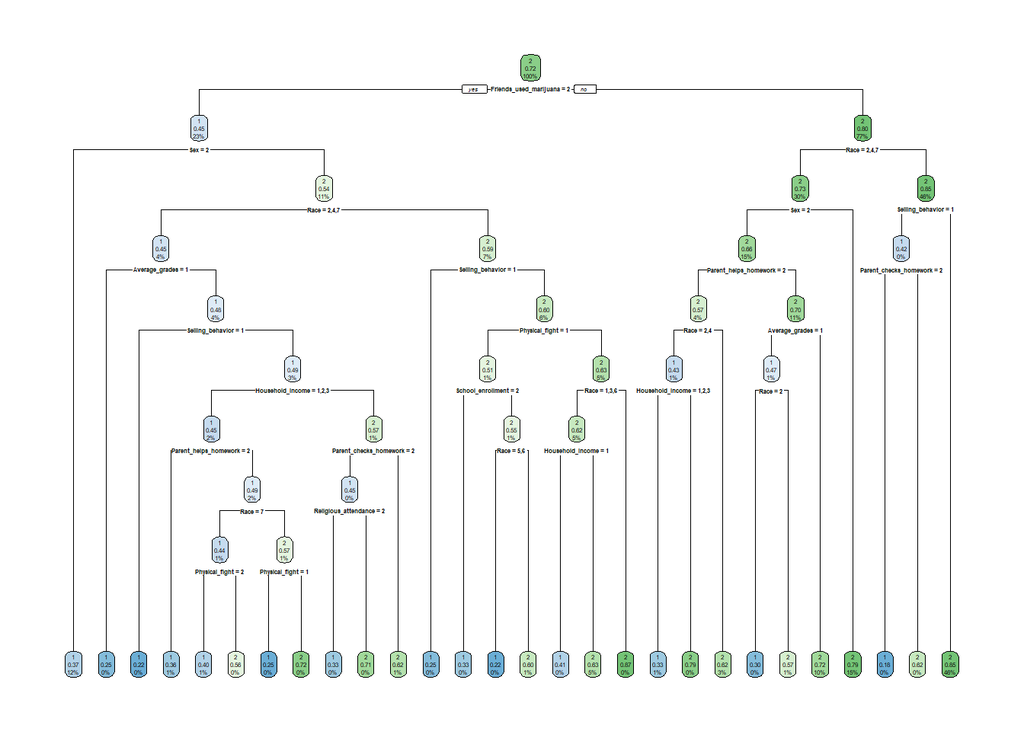

```r
# Plot Final Multi-Class Decision Tree display the final multi-class decision tree

rpart.plot(multi_model)
```

The multi-class decision tree shows multiple splits based on behavioral and social factors. Compared to the binary tree, this model is more complex, with deeper branches used to separate different levels of marijuana use.

### 5.Regression (Alcohol_use_days)

The predictors again include the same demographic, behavioral, and social variables. The variables Marijuana_use and Marijuana_use_level were excluded to ensure that alcohol use is predicted independently without using related marijuana outcomes.

#### Model Setup

```r
# Regression Tree Setup create datasets for predicting alcohol use days

train_reg <- train_data[, -which(names(train_data) %in% c("Marijuana_use", "Marijuana_use_level"))]
test_reg  <- test_data[, -which(names(test_data) %in% c("Marijuana_use", "Marijuana_use_level"))]
```

#### Hyperparameter Tuning

```r
# Regression Tree Tuning Grid test different cp values for the regression tree

reg_grid <- expand.grid(
  cp = seq(0.001, 0.02, by = 0.002)
)
```

```r
# Tune Regression Tree use cross-validation to find the best cp value

set.seed(123)

reg_cv <- train(
  Alcohol_use_days ~ .,
  data = train_reg,
  method = "rpart",
  trControl = ctrl,
  tuneGrid = reg_grid
)

reg_cv
```

```
## CART
##
## 6440 samples
##   11 predictor
##
## No pre-processing
## Resampling: Cross-Validated (10 fold)
## Summary of sample sizes: 5796, 5796, 5796, 5796, 5796, 5796, ...
## Resampling results across tuning parameters:
##
##   cp     RMSE      Rsquared    MAE
##   0.001  1.660142  0.11645685  1.167697
##   0.003  1.656763  0.11852430  1.177641
##   0.005  1.666782  0.10829840  1.190239
##   0.007  1.669571  0.10547519  1.197634
##   0.009  1.676559  0.09779068  1.206290
##   0.011  1.676929  0.09713340  1.208984
##   0.013  1.676929  0.09713340  1.208984
##   0.015  1.676929  0.09713340  1.208984
##   0.017  1.676929  0.09713340  1.208984
##   0.019  1.676929  0.09713340  1.208984
##
## RMSE was used to select the optimal model using the smallest value.
## The final value used for the model was cp = 0.003.
```

Cross-validation was used to tune the regression tree by testing different cp values. The model was evaluated using RMSE, and the best value was selected based on the lowest error. The optimal parameter was cp = 0.003, which produced the smallest RMSE among the tested values.

```r
# Get the Best cp Value xtract the optimal cp value for the regression tree

best_reg_cp <- reg_cv$bestTune$cp
best_reg_cp
```

```
## [1] 0.003
```

#### Final Model Fitting

```r
# Fit Final Regression Tree fit the final regression tree using the best cp value

reg_model <- rpart(
  Alcohol_use_days ~ .,
  data = train_reg,
  method = "anova",
  cp = best_reg_cp
)
```

#### Model Evaluation

```r
# Evaluate Regression Tree make predictions on the test data

reg_pred <- predict(reg_model, test_reg)

# calculate mse
reg_mse <- mean((reg_pred - test_reg$Alcohol_use_days)^2)
reg_mse
```

```
## [1] 2.826877
```

```r
# calculate rmse
reg_rmse <- sqrt(reg_mse)
reg_rmse
```

```
## [1] 1.681332
```

The regression tree was evaluated using the test data. The model produced an MSE of about 2.83 and an RMSE of about 1.68. These values represent the average error between the predicted and actual number of alcohol use days, showing that the model captures general trends but still has some prediction error.

#### Model Interpretation

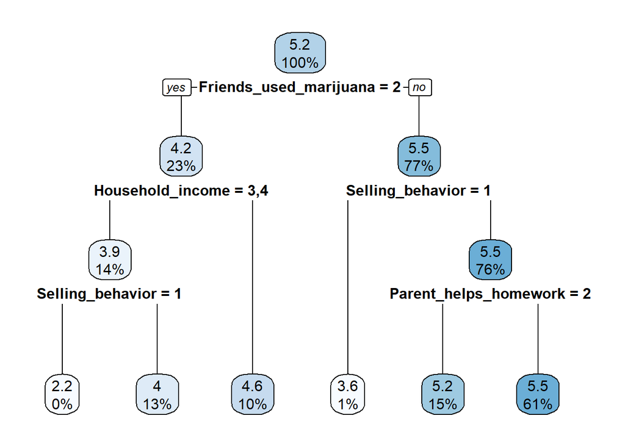

```r
# Plot Final Regression Tree display the final regression tree

rpart.plot(reg_model)
```

The regression tree shows that the main split is based on whether friends use marijuana. This indicates that peer influence is an important factor in predicting alcohol use days.

For individuals whose friends use marijuana, the predicted number of alcohol use days is lower, with further differences based on household income and selling behavior. For those whose friends do not use marijuana, higher alcohol use is observed, with additional splits based on selling behavior and parental involvement.

This suggests that both social environment and family factors influence alcohol use patterns.

### Model Comparison

```r
# # Create Model Performance Table combine model results into one summary table

performance_table <- data.frame(
  Model = c(
    "Decision Tree",
    "Random Forest",
    "Boosting",
    "Multi-Class Tree",
    "Regression Tree"
  ),
  Metric = c(
    "Accuracy",
    "Accuracy",
    "Accuracy",
    "Accuracy",
    "MSE"
  ),
  Value = c(
    tree_accuracy,
    rf_accuracy,
    boost_accuracy,
    multi_accuracy,
    reg_mse
  )
)

performance_table
```

```
##              Model   Metric     Value
## 1    Decision Tree Accuracy 0.8481334
## 2    Random Forest Accuracy 0.8481334
## 3         Boosting Accuracy 0.8492207
## 4 Multi-Class Tree Accuracy 0.7618702
## 5  Regression Tree      MSE 2.8268768
```

```r
# Format Model Performance Table round values for easier presentation

performance_table$Value <- round(performance_table$Value, 3)

performance_table
```

```
##              Model   Metric Value
## 1    Decision Tree Accuracy 0.848
## 2    Random Forest Accuracy 0.848
## 3         Boosting Accuracy 0.849
## 4 Multi-Class Tree Accuracy 0.762
## 5  Regression Tree      MSE 2.827
```

### Ethical Considerations

When interpreting the results, it is important not to make assumptions about individuals or groups. The model shows patterns in the data, but this does not mean it proves cause and effect.

For example, demographic or behavioral variables may be linked to substance use, but they should not be used to label or stereotype people. Misunderstanding these results can lead to unfair conclusions. Furthermore, risk of misusing model predictions in decision-making. For instance, if these results were used by schools or organizations, individuals labeled as “high risk” could be unfairly targeted or monitored. This may lead to unequal treatment.

Therefore, the results should be used carefully, focusing on general trends rather than judging specific individuals or groups.